$$\large{\textbf{Universidade Federal do Paraná - Departamento de Estatística}}$$

$$\large{\textbf{Lineu Alberto Cavazani de Freitas}}$$

$$\large{\textbf{Orientador: Prof. Cesar Augusto Taconeli}}$$

$$\large{\textbf{Coorientador: Prof. José Luiz Padilha da Silva}}$$

# 1 O experimento

O objetivo do experimento foi investigar como a reatividade emocional influencia as respostas comportamentais de ovelhas.

20 ovelhas, classificadas como reativas ou não reativas ao isolamento social temporário, foram escovadas por um humano familiar.

O experimento foi realizado na fazenda experimental INRA La Fage, Roqueford, França em Setembro de 2015. 20 ovelhas com 15 meses de idade, não gestantes e não amamentando foram observadas. As ovelhas pertencem a **2 linhagens genéticas**, uma mais reativa e outra menos reativa ao isolamento social.

A reatividade dos animais foi definida num experimento anterior no qual foram escolhidos 11 animais considerados pouco reativos e 9 considerados reativos ao isolamento social.

O experimento foi conduzido em **três sessões**:

- **Sessão 1** - Com uma grade de metal separando o animal testado dos demais animais, sem distância entre eles.
- **Sessão 2** - Com duas grades de metal separando o animal testado dos demais animais a uma distância de 1.7 m; a sessão 2 foi uma novidade para todos os animais no experimento, isto é, não fez parte da fase da adaptação.
- **Sessão 3** - Idêntica à sessão 1

Além disso, as sessões de testes ocorreram dois dias após a fase de adaptação dos animais ao equipamento e aos humanos, cada animal foi observado em **3 fases** diferentes:

- **Fase 1** - Pré escovação, 2 minutos e 30 segundos
- **Fase 2** - Escovação, 3 minutos
- **Fase 3** - Pós escovação, 2 minutos e 30 segundos

Dois tipos de resposta foram observadas:

- dados de variação de postura (**contagens**), com 8 respostas observadas
- dados de tempo nas posturas (**proporções contínuas**), com outras 9 respostas

As variáveis explicativas do experimento são:

1. **sessao** - Fator com níveis 1, 2 e 3
2. **linhagem** - Fator com níveis s+ (linhagem reativa) e s- (linhagem não reativa)
3. **tempo** - Fator com três níveis: Antes, durante e depois (da intervenção)

Duas respostas foram selecionadas para análise:

1. Número de mudanças de postura de orelha (contagem)
2. Proporção do tempo em que os animais permaneceram com as orelhas neutras (proporção contínua)

# 2 Ajuste das bases

Os dados foram tabulados em duas planilhas diferentes. Além disso, na época do experimento original, havia interesse em um contraste específico no que diz respeito às sessões experimentais.

## 2.1 Base de contagem

```r
setwd("~/Dropbox/IC/Pesquisa/Dados")

## Leitura dos dados
count <- read.csv2("DataCont.csv", header = T, sep = ',')

## Alterando os contrastes default para os contrastes de interesse
count$sessaoR <- count$sessao

count$sessaoR <- relevel(count$sessaoR, ref = 'Se3')
contrasts(count$sessaoR) <- 'contr.helmert'

contrasts(count$sessaoR)[,1] <- contrasts(count$sessaoR)[,1]/2
contrasts(count$sessaoR)[,2] <- contrasts(count$sessaoR)[,2]/3
```

## 2.2 Base de proporção

```r
setwd("~/Dropbox/IC/Pesquisa/Dados")

## Leitura dos dados
prop <- read.csv2("DataProp.csv", header = T, sep = ';')

## Alterando os contrastes default para os contrastes de interesse

prop$sessaoR <- prop$sessao

prop$sessaoR <- relevel(prop$sessaoR, ref = 'Se3')
contrasts(prop$sessaoR) <- 'contr.helmert'

contrasts(prop$sessaoR)[,1] <- contrasts(prop$sessaoR)[,1]/2
contrasts(prop$sessaoR)[,2] <- contrasts(prop$sessaoR)[,2]/3

# Criando um fator combinando animal e sessao
prop$animals <- factor(prop$animal):prop$sessao

# Retirando a resposta com NAs (resporelha)
prop2 <- prop[,-c(8)]

# Gerando a resposta
prop2$neutra <- 1-prop2$resporelha2
#sum(prop2$neutra == 1)
#sum(prop2$neutra == 0)

# Aplicando a correção na resposta para aplicação da dist beta
prop2$neutra.be <- ((prop2$neutra*(180-1))+(0.5))/180
#sum(prop2$neutra.be == 1)
#sum(prop2$neutra.be == 0)
```

# 3 Análise Descritiva

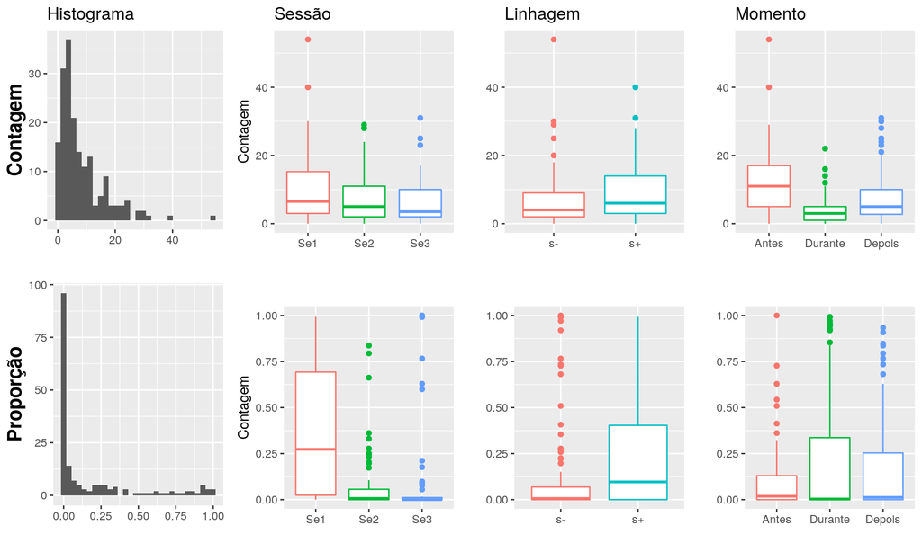

```r
count$momento <- ordered(count$tempo, levels=c("Antes", "Durante", "Depois"))
prop2$momento <- ordered(prop2$tempo, levels=c("Antes", "Durante", "Depois"))

library(ggplot2)
g1 <- ggplot(count, aes(x = norelha)) +
  geom_histogram() + xlab('')+ ylab('Contagem')+
  ggtitle('Histograma') + theme(axis.title=element_text(size=15,face="bold"))

g2<- ggplot(count, aes(x=sessao, y=norelha, color=sessao)) +
  geom_boxplot()+ xlab('')+ ylab('Contagem') +
  theme(legend.title=element_blank()) + scale_color_discrete(guide = F) +
  ggtitle('Sessão')

g3<- ggplot(count, aes(x=linhagem, y=norelha, color=linhagem)) +
  geom_boxplot()+ xlab('')+ ylab('') +
  theme(legend.title=element_blank()) + scale_color_discrete(guide = F)+
  ggtitle('Linhagem')

g4<- ggplot(count, aes(x=momento, y=norelha, color=factor(momento))) +
  geom_boxplot()+ xlab('')+ ylab('') +
  theme(legend.title=element_blank()) + scale_color_discrete(guide = F)+
  ggtitle('Momento')

g5 <- ggplot(prop2, aes(x = neutra)) +
  geom_histogram() + xlab('')+ ylab('Proporção')+
  theme(axis.title=element_text(size=15,face="bold"))

g6<- ggplot(prop2, aes(x=sessao, y=neutra, color=sessao)) +
  geom_boxplot()+ xlab('')+ ylab('Contagem') +
  theme(legend.title=element_blank()) + scale_color_discrete(guide = F)+
  ggtitle('')

g7<- ggplot(prop2, aes(x=linhagem, y=neutra, color=linhagem)) +
  geom_boxplot()+ xlab('')+ ylab('') +
  theme(legend.title=element_blank()) + scale_color_discrete(guide = F)+
  ggtitle('')

g8<- ggplot(prop2, aes(x=momento, y=neutra, color=momento)) +
  geom_boxplot()+ xlab('')+ ylab('') +
  theme(legend.title=element_blank()) + scale_color_discrete(guide = F)+
  ggtitle('')

library(gridExtra)
grid.arrange(g1, g2, g3, g4, g5, g6, g7, g8, ncol=4, nrow=2)
```

# 4 Ajuste dos modelos

```r
library(gamlss)
```

## 4.1 Número de mudanças de postura de orelha

Distribuições

- PO
- NBII
- ZIP
- ZINBI
- ZAP
- ZANB

### 4.1.1 Ajustes

```r
# Criando um fator combinando animal e sessao
count$animals <- factor(count$animal):count$sessao

m19 <- gamlss(norelha ~ sessaoR + tempo + linhagem
              + (sessaoR + tempo + linhagem)^2 +
                re(random = list(animal=~1, animals=~1)),
              data = count, family = PO())

m20 <- gamlss(norelha ~ sessaoR + tempo + linhagem
              + (sessaoR + tempo + linhagem)^2+
                re(random = list(animal=~1, animals=~1)),
              data = count, family = NBI())

m21 <- gamlss(norelha ~ sessaoR + tempo + linhagem
              + (sessaoR + tempo + linhagem)^2+
                re(random = list(animal=~1, animals=~1)),
              data = count, family = ZIP())

m22 <- gamlss(norelha ~ sessaoR + tempo + linhagem
              + (sessaoR + tempo + linhagem)^2+
                re(random = list(animal=~1, animals=~1)),
              nu.formula = norelha ~ sessaoR + tempo +
                linhagem+ (sessaoR + tempo + linhagem)^2,
              data = count, family = ZINBI(),
              method = RS(100))

m23 <- gamlss(norelha ~ sessaoR + tempo + linhagem
              + (sessaoR + tempo + linhagem)^2+
                re(random = list(animal=~1, animals=~1)),
              data = count, family = ZAP())

 m24 <- gamlss(norelha ~ sessaoR + tempo + linhagem
               + (sessaoR + tempo + linhagem)^2+
                 re(random = list(animal=~1, animals=~1), method = "REML"),
               nu.formula = norelha ~ sessaoR + tempo + linhagem
               + (sessaoR + tempo + linhagem)^2,
               data = count, family = ZANBI())
```

### 4.1.2 Medidas de qualidade, para selecionar a família

```r
tab <- data.frame("Modelo" = c(
  'PO' , 'NBI', 'ZIP', 'ZINBI', 'ZAP',
  'ZANB'),
  "AIC"       = rep(NA, 6),
  "BIC"    = rep(NA, 6),
  "Deviance" = rep(NA, 6),
  "logLik"  = rep(NA, 6),
  "df"  = rep(NA, 6),
  "Conv" = rep(NA, 6),

  check.names = FALSE)

tab[1, 2] <- m19$aic
tab[1, 3] <- m19$sbc
tab[1, 4] <- m19$G.deviance
tab[1, 5] <- logLik(m19)
tab[1, 6] <- m19$df.fit
tab[1, 7] <- m19$converged

tab[2, 2] <- m20$aic
tab[2, 3] <- m20$sbc
tab[2, 4] <- m20$G.deviance
tab[2, 5] <- logLik(m20)
tab[2, 6] <- m20$df.fit
tab[2, 7] <- m20$converged

tab[3, 2] <- m21$aic
tab[3, 3] <- m21$sbc
tab[3, 4] <- m21$G.deviance
tab[3, 5] <- logLik(m21)
tab[3, 6] <- m21$df.fit
tab[3, 7] <- m21$converged

tab[4, 2] <- m22$aic
tab[4, 3] <- m22$sbc
tab[4, 4] <- m22$G.deviance
tab[4, 5] <- logLik(m22)
tab[4, 6] <- m22$df.fit
tab[4, 7] <- m22$converged

tab[5, 2] <- m23$aic
tab[5, 3] <- m23$sbc
tab[5, 4] <- m23$G.deviance
tab[5, 5] <- logLik(m23)
tab[5, 6] <- m23$df.fit
tab[5, 7] <- m23$converged

tab[6, 2] <- m24$aic
tab[6, 3] <- m24$sbc
tab[6, 4] <- m24$G.deviance
tab[6, 5] <- logLik(m24)
tab[6, 6] <- m24$df.fit
tab[6, 7] <- m24$converged
```

```r
library(knitr)

kable(tab)
```

| Modelo | AIC | BIC | Deviance | logLik | df | Conv |
| --- | --- | --- | --- | --- | --- | --- |
| PO | 1192.008 | 1344.306 | 1096.6111 | -548.3056 | 47.69822 | TRUE |
| NBI | 1054.474 | 1204.850 | 960.2823 | -480.1412 | 47.09603 | TRUE |
| ZIP | 1127.461 | 1314.515 | 1010.2945 | -505.1473 | 58.58337 | TRUE |
| ZINBI | 1046.091 | 1244.497 | 921.8137 | -460.9068 | 62.13861 | TRUE |
| ZAP | 1137.749 | 1323.446 | 1021.4333 | -510.7166 | 58.15806 | TRUE |
| ZANB | 1046.170 | 1247.390 | 920.1308 | -460.0654 | 63.01976 | TRUE |

### 4.1.3 Reajuste dos modelos

Reajuste 1

- Retirando interações de nu

```r
m24r1 <- gamlss(formula = norelha ~ sessaoR + tempo + linhagem +
                  (sessaoR + tempo + linhagem)^2 +
                  re(random = list(animal = ~1, animals = ~1), method = "REML"),
                nu.formula = norelha ~ sessaoR + tempo + linhagem,
                family = ZANBI(), data = count)
```

Reajuste 2

- Retirando interações de mu e nu

```r
m24r2 <- gamlss(formula = norelha ~ sessaoR + tempo + linhagem +
                  re(random = list(animal = ~1, animals = ~1)),
                nu.formula = norelha ~ sessaoR + tempo + linhagem,
                family = ZANBI(), data = count)
```

Reajuste 3

- Retirando interações de mu e todas as covariáveis de nu

```r
m24r3 <- gamlss(formula = norelha ~ sessaoR + tempo + linhagem +
                  re(random = list(animal = ~1, animals = ~1)),
                family = ZANBI(), data = count)
```

### 4.1.4 TRV

Se o p-valor for pequeno, a variável retirada é significativa

```r
tab2 <- data.frame("Modelo" = c(
  'Completo' , 'Reajuste 1',
  'Reajuste 2', 'Reajuste 3'),
  "AIC"       = rep(NA, 4),
  "BIC"    = rep(NA, 4),
  "Deviance" = rep(NA, 4),
  "logLik"  = rep(NA, 4),
  "df"  = rep(NA, 4),
  "Conv" = rep(NA, 4),
  "P-val" = rep(NA, 4),
  check.names = FALSE)

tab2[1, 2] <- m24$aic
tab2[1, 3] <- m24$sbc
tab2[1, 4] <- m24$G.deviance
tab2[1, 5] <- logLik(m24)
tab2[1, 6] <- m24$df.fit
tab2[1, 7] <- m24$converged
tab2[1, 8] <- '-'

tab2[2, 2] <- m24r1$aic
tab2[2, 3] <- m24r1$sbc
tab2[2, 4] <- m24r1$G.deviance
tab2[2, 5] <- logLik(m24r1)
tab2[2, 6] <- m24r1$df.fit
tab2[2, 7] <- m24r1$converged
tab2[2, 8] <- round(LR.test(m24r1, m24, print = F)$p.val, 2)

tab2[3, 2] <- m24r2$aic
tab2[3, 3] <- m24r2$sbc
tab2[3, 4] <- m24r2$G.deviance
tab2[3, 5] <- logLik(m24r2)
tab2[3, 6] <- m24r2$df.fit
tab2[3, 7] <- m24r2$converged
tab2[3, 8] <- round(LR.test(m24r2, m24, print = F)$p.val, 2)

tab2[4, 2] <- m24r3$aic
tab2[4, 3] <- m24r3$sbc
tab2[4, 4] <- m24r3$G.deviance
tab2[4, 5] <- logLik(m24r3)
tab2[4, 6] <- m24r3$df.fit
tab2[4, 7] <- m24r3$converged
tab2[4, 8] <- round(LR.test(m24r3, m24, print = F)$p.val, 2)
```

```r
kable(tab2)
```

| Modelo | AIC | BIC | Deviance | logLik | df | Conv | P-val |
| --- | --- | --- | --- | --- | --- | --- | --- |
| Completo | 1046.170 | 1247.390 | 920.1308 | -460.0654 | 63.01976 | TRUE | - |
| Reajuste 1 | 1036.359 | 1212.034 | 926.3192 | -463.1596 | 55.01976 | TRUE | 0.63 |
| Reajuste 2 | 1022.391 | 1172.740 | 928.2159 | -464.1080 | 47.08758 | TRUE | 0.94 |
| Reajuste 3 | 1036.969 | 1171.353 | 952.7935 | -476.3968 | 42.08758 | TRUE | 0.05 |

### 4.1.5 Conclusões

Sendo assim o melhor modelo ajustado por sessão, linhagem, tempo para mu e nu e 2 efeitos aleatórios para mu

## 4.2 Proporção do tempo com orelhas em posição neutra

Distribuições

- BE()
- BEINF()

### 4.2.1 Ajustes

```r
m1.be <- gamlss(neutra.be ~ sessaoR + tempo + linhagem
                + (sessaoR + tempo + linhagem)^2 +
                  re(random = list(animal=~1, animals=~1)),
                data = prop2, family = BE())

m1.beinf <- gamlss(neutra ~ sessaoR + tempo + linhagem
                   + (sessaoR + tempo + linhagem)^2 +
                     re(random = list(animal=~1, animals=~1)),
                   nu.formula = ~ sessaoR + tempo + linhagem,
                   data = prop2, family = BEINF())
```

### 4.2.2 Análise gráfica para seleção do modelo

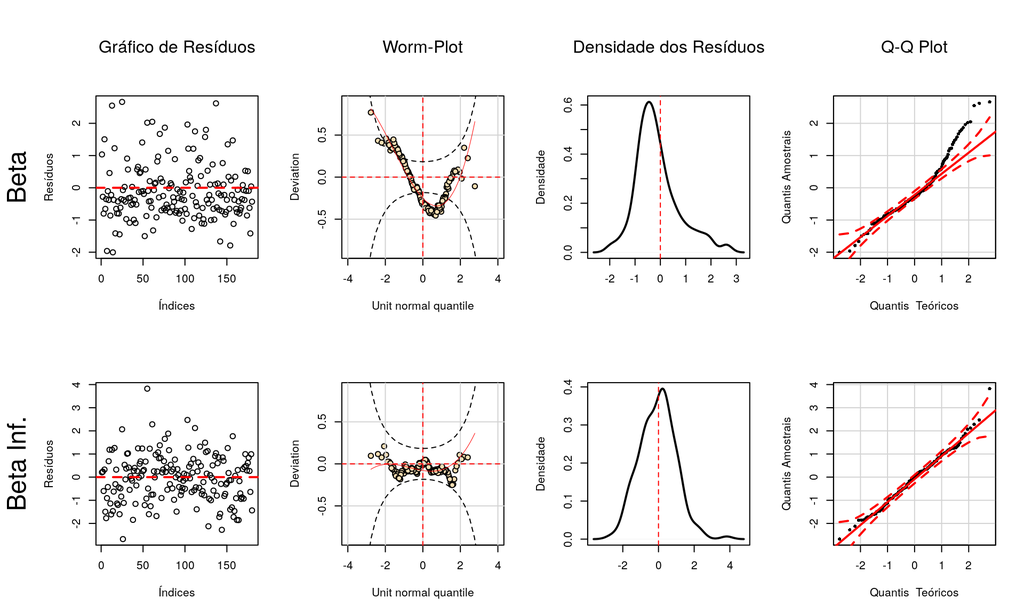

```r
par(mfrow = c(2,4), par(oma=c(0,3,3,0)))
res.be    <- m1.be$residuals
res.beinf <- m1.beinf$residuals

plot(res.be, xlab = 'Índices', ylab = 'Resíduos')
abline(h = 0, lwd = 2, lty = 2, col =2)
mtext('Gráfico de Resíduos', side=3, line=3, cex=1 )
mtext("Beta", side=2, line=5, cex=1.5 )

wp(m1.be, xlab = 'Unit normal quantile',
   ylab = 'Deviation')
mtext("Worm-Plot", side=3, line=3, cex=1 )

plot(density(res.be), xlab = '', ylab = 'Densidade',
     main = '', lwd = 2)
abline(v=0, lty = 2, col=2)
mtext("Densidade dos Resíduos", side=3, line=3, cex=1 )

car::qqPlot(res.be, dist = 'norm', envelope = .95,
            xlab = 'Quantis  Teóricos',
            ylab = 'Quantis Amostrais',
            main = "",
            lwd=2, pch=16, id = FALSE,
            col.lines = 2)
mtext("Q-Q Plot", side=3, line=3, cex=1 )

plot(res.beinf, xlab = 'Índices', ylab = 'Resíduos', main = '')
abline(h = 0, lwd = 2, lty = 2, col =2)
mtext("Beta Inf.", side=2, line=5, cex=1.5 )

wp(m1.beinf, xlab = 'Unit normal quantile',
   ylab = 'Deviation', main = '')
plot(density(res.beinf), xlab = '', ylab = 'Densidade',
     main = '', lwd = 2)
abline(v=0, lty = 2, col=2)

car::qqPlot(res.beinf, dist = 'norm', envelope = .95,
            xlab = 'Quantis  Teóricos',
            ylab = 'Quantis Amostrais',
            main = "",
            lwd=2, pch=16, id = FALSE,
            col.lines = 2)
```

A análise gráfica indica que o modelo com distribuição beta inflacionada está melhor ajustado.

### 4.2.3 Reajuste dos modelos

Reajuste 1

- Retirando interações de mu

```r
m1.beinf.drop1 <-
  gamlss(formula = neutra ~ sessaoR + tempo + linhagem +
           re(random = list(animal = ~1, animals = ~1)),
         nu.formula = ~sessaoR + tempo + linhagem, family = BEINF(),
         data = prop2)
```

Reajuste 2

- Retirando interações de mu e todas as covariáveis de nu

```r
m1.beinf.drop2 <-
  gamlss(formula = neutra ~ sessaoR + tempo + linhagem +
           re(random = list(animal = ~1, animals = ~1)),
         family = BEINF(),
         data = prop2)
```

### 4.2.4 TRV

Se o p-valor for pequeno, a variável retirada é significativa

```r
tab <- data.frame("Modelo" = c(
  'Completo' , 'drop1', 'drop2'),
  "AIC"       = rep(NA, 3),
  "BIC"    = rep(NA, 3),
  "Deviance" = rep(NA, 3),
  "logLik"  = rep(NA, 3),
  "df"  = rep(NA, 3),
  "P-val" = rep(NA, 3),

  check.names = FALSE)

tab[1, 2] <- m1.beinf$aic
tab[1, 3] <- m1.beinf$sbc
tab[1, 4] <- m1.beinf$G.deviance
tab[1, 5] <- logLik(m1.beinf)
tab[1, 6] <- m1.beinf$df.fit
tab[1, 7] <- '-'

tab[2, 2] <- m1.beinf.drop1$aic
tab[2, 3] <- m1.beinf.drop1$sbc
tab[2, 4] <- m1.beinf.drop1$G.deviance
tab[2, 5] <- logLik(m1.beinf.drop1)
tab[2, 6] <- m1.beinf.drop1$df.fit
tab[2, 7] <- round(LR.test(m1.beinf.drop1, m1.beinf, print = F)$p.val, 2)

tab[3, 2] <- m1.beinf.drop2$aic
tab[3, 3] <- m1.beinf.drop2$sbc
tab[3, 4] <- m1.beinf.drop2$G.deviance
tab[3, 5] <- logLik(m1.beinf.drop2)
tab[3, 6] <- m1.beinf.drop2$df.fit
tab[3, 7] <- round(LR.test(m1.beinf.drop2, m1.beinf, print = F)$p.val, 4)
```

```r
kable(tab)
```

| Modelo | AIC | BIC | Deviance | logLik | df | P-val |
| --- | --- | --- | --- | --- | --- | --- |
| Completo | 98.08186 | 284.5782 | -18.735470 | 9.367735 | 58.40866 | - |
| drop1 | 97.52928 | 246.4183 | 4.268355 | -2.134177 | 46.63046 | 0.03 |
| drop2 | 138.93015 | 271.8544 | 55.669221 | -27.834610 | 41.63046 | 0 |

O trv indica que o modelo inicialmente ajustado deve ser mantido

### 4.2.5 Análise de resíduos

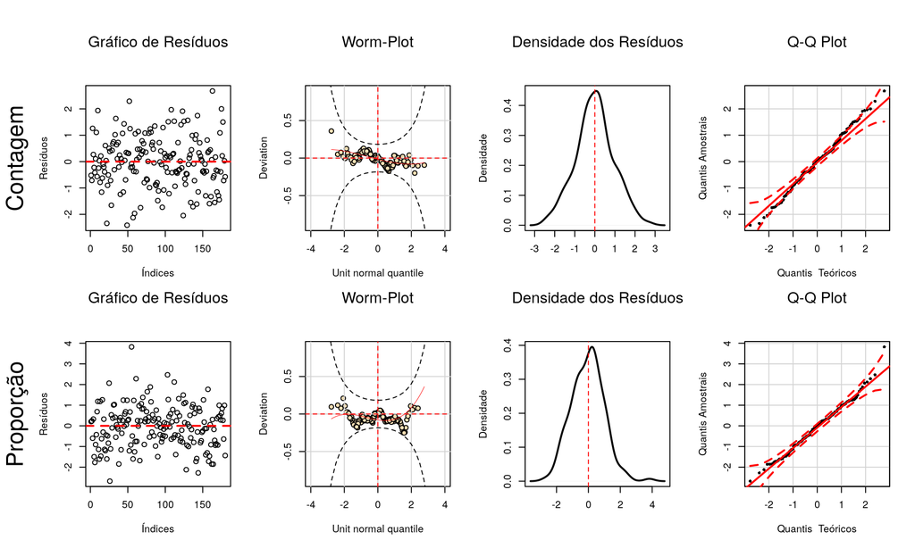

```r
par(mfrow = c(2,4), par(oma=c(0,3,3,0)))
res.1    <- m24r2$residuals

plot(res.1, xlab = 'Índices', ylab = 'Resíduos')
abline(h = 0, lwd = 2, lty = 2, col =2)
mtext('Gráfico de Resíduos', side=3, line=3, cex=1 )
mtext("Contagem", side=2, line=5, cex=1.5 )

wp(m24r2, xlab = 'Unit normal quantile',
   ylab = 'Deviation')
mtext("Worm-Plot", side=3, line=3, cex=1 )

plot(density(res.1), xlab = '', ylab = 'Densidade',
     main = '', lwd = 2)
abline(v=0, lty = 2, col = 2)
mtext("Densidade dos Resíduos", side=3, line=3, cex=1 )

car::qqPlot(res.1, dist = 'norm', envelope = .95,
            xlab = 'Quantis  Teóricos',
            ylab = 'Quantis Amostrais',
            main = "",
            lwd=2, pch=16, id = FALSE,
            col.lines = 2)
mtext("Q-Q Plot", side=3, line=3, cex=1 )

res.1    <- m1.beinf$residuals

plot(res.1, xlab = 'Índices', ylab = 'Resíduos')
abline(h = 0, lwd = 2, lty = 2, col =2)
mtext('Gráfico de Resíduos', side=3, line=3, cex=1 )
mtext("Proporção", side=2, line=5, cex=1.5 )

wp(m1.beinf, xlab = 'Unit normal quantile',
   ylab = 'Deviation')
mtext("Worm-Plot", side=3, line=3, cex=1 )

plot(density(res.1), xlab = '', ylab = 'Densidade',
     main = '', lwd = 2)
abline(v=0, lty = 2, col = 2)
mtext("Densidade dos Resíduos", side=3, line=3, cex=1 )

car::qqPlot(res.1, dist = 'norm', envelope = .95,
            xlab = 'Quantis  Teóricos',
            ylab = 'Quantis Amostrais',
            main = "",
            lwd=2, pch=16, id = FALSE,
            col.lines = 2)
mtext("Q-Q Plot", side=3, line=3, cex=1 )
```

# 5 Resumo dos modelos

```r
summary(m24r2)
```

```
## Family:  c("ZANBI", "Zero Altered Negative binomial type I")
##
## Call:  gamlss(formula = norelha ~ sessaoR + tempo + linhagem +
##     re(random = list(animal = ~1, animals = ~1)), nu.formula = norelha ~
##     sessaoR + tempo + linhagem, family = ZANBI(), data = count)
##
## Fitting method: RS()
##
## ------------------------------------------------------------------
## Mu link function:  log
## Mu Coefficients:
##              Estimate Std. Error t value Pr(>|t|)
## (Intercept)   2.45897    0.07714  31.876  < 2e-16 ***
## sessaoR1      0.42118    0.10562   3.988  0.00011 ***
## sessaoR2     -0.16343    0.09255  -1.766  0.07971 .
## tempoDepois  -0.43174    0.09741  -4.432 1.93e-05 ***
## tempoDurante -1.05553    0.11391  -9.266 4.52e-16 ***
## linhagems+    0.28322    0.08584   3.299  0.00124 **
## ---
## Signif. codes:  0 '***' 0.001 '**' 0.01 '*' 0.05 '.' 0.1 ' ' 1
##
## ------------------------------------------------------------------
## Sigma link function:  log
## Sigma Coefficients:
##             Estimate Std. Error t value Pr(>|t|)
## (Intercept)  -1.9121     0.2148  -8.901 3.58e-15 ***
## ---
## Signif. codes:  0 '***' 0.001 '**' 0.01 '*' 0.05 '.' 0.1 ' ' 1
##
## ------------------------------------------------------------------
## Nu link function:  logit
## Nu Coefficients:
##              Estimate Std. Error t value Pr(>|t|)
## (Intercept)   -4.1780     1.0714  -3.899 0.000152 ***
## sessaoR1      -2.6613     1.0911  -2.439 0.016045 *
## sessaoR2       0.4330     0.7312   0.592 0.554707
## tempoDepois    1.4892     1.1487   1.296 0.197062
## tempoDurante   2.7598     1.0831   2.548 0.011969 *
## linhagems+    -1.1191     0.6379  -1.754 0.081686 .
## ---
## Signif. codes:  0 '***' 0.001 '**' 0.01 '*' 0.05 '.' 0.1 ' ' 1
##
## ------------------------------------------------------------------
## NOTE: Additive smoothing terms exist in the formulas:
##  i) Std. Error for smoothers are for the linear effect only.
## ii) Std. Error for the linear terms maybe are not accurate.
## ------------------------------------------------------------------
## No. of observations in the fit:  180
## Degrees of Freedom for the fit:  47.08758
##       Residual Deg. of Freedom:  132.9124
##                       at cycle:  14
##
## Global Deviance:     928.2159
##             AIC:     1022.391
##             SBC:     1172.74
```

```r
summary(m1.beinf)
```

```
## Family:  c("BEINF", "Beta Inflated")
##
## Call:  gamlss(formula = neutra ~ sessaoR + tempo + linhagem +
##     (sessaoR + tempo + linhagem)^2 + re(random = list(animal = ~1,
##     animals = ~1)), nu.formula = ~sessaoR + tempo +
##     linhagem, family = BEINF(), data = prop2)
##
## Fitting method: RS()
##
## ------------------------------------------------------------------
## Mu link function:  logit
## Mu Coefficients:
##                         Estimate Std. Error t value Pr(>|t|)
## (Intercept)             -1.83182    0.25098  -7.299 3.28e-11 ***
## sessaoR1                -0.01692    0.49698  -0.034  0.97290
## sessaoR2                -0.92874    0.43316  -2.144  0.03401 *
## tempoDepois              0.12334    0.32158   0.384  0.70198
## tempoDurante             0.39479    0.34268   1.152  0.25154
## linhagems+               0.27923    0.30909   0.903  0.36811
## sessaoR1:tempoDepois     0.75464    0.62379   1.210  0.22872
## sessaoR2:tempoDepois     0.20307    0.47912   0.424  0.67244
## sessaoR1:tempoDurante    0.72014    0.56791   1.268  0.20720
## sessaoR2:tempoDurante   -1.29222    0.53071  -2.435  0.01635 *
## sessaoR1:linhagems+      1.16999    0.50621   2.311  0.02250 *
## sessaoR2:linhagems+      0.62369    0.43168   1.445  0.15109
## tempoDepois:linhagems+   0.51763    0.42995   1.204  0.23095
## tempoDurante:linhagems+  1.39752    0.43835   3.188  0.00182 **
## ---
## Signif. codes:  0 '***' 0.001 '**' 0.01 '*' 0.05 '.' 0.1 ' ' 1
##
## ------------------------------------------------------------------
## Sigma link function:  logit
## Sigma Coefficients:
##             Estimate Std. Error t value Pr(>|t|)
## (Intercept) -0.36485    0.09451  -3.861 0.000183 ***
## ---
## Signif. codes:  0 '***' 0.001 '**' 0.01 '*' 0.05 '.' 0.1 ' ' 1
##
## ------------------------------------------------------------------
## Nu link function:  log
```

[output cut: 17 more lines]

```
## Signif. codes:  0 '***' 0.001 '**' 0.01 '*' 0.05 '.' 0.1 ' ' 1
##
## ------------------------------------------------------------------
## NOTE: Additive smoothing terms exist in the formulas:
##  i) Std. Error for smoothers are for the linear effect only.
## ii) Std. Error for the linear terms maybe are not accurate.
## ------------------------------------------------------------------
## No. of observations in the fit:  180
## Degrees of Freedom for the fit:  58.40867
##       Residual Deg. of Freedom:  121.5913
##                       at cycle:  12
##
## Global Deviance:     -18.73547
##             AIC:     98.08186
##             SBC:     284.5782
```

# 6 Explorando efeitos aleatórios

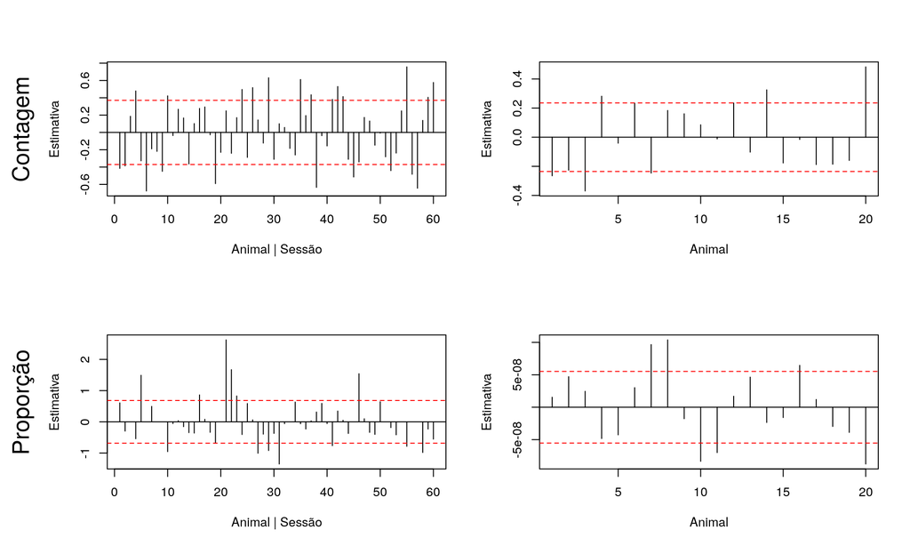

```r
par(mfrow = c(2,2), par(oma=c(0,3,0,0)))

coef <- getSmo(m24r2)$coef

# animal dentro de sessão
re.animals<-(coef$random[2])
re.animals<- as.data.frame(re.animals)

plot(re.animals$X.Intercept., type = 'h',
     main = '',
     xlab = 'Animal | Sessão', ylab = 'Estimativa')

abline(h=0)

abline(h= mean(re.animals$X.Intercept.) +
         sd(re.animals$X.Intercept.),
       lty = 2, col = 2)

abline(h= mean(re.animals$X.Intercept.) -
         sd(re.animals$X.Intercept.),
       lty = 2, col = 2)

mtext("Contagem", side=2, line=5, cex=1.5 )

# animal
re.animal<-(coef$random[1])
re.animal<- as.data.frame(re.animal)

plot(re.animal$X.Intercept., type = 'h',
     main = '',
     xlab = 'Animal', ylab = 'Estimativa')


abline(h=0)

abline(h= mean(re.animal$X.Intercept.) +
         sd(re.animal$X.Intercept.),
       lty = 2, col = 2)

abline(h= mean(re.animal$X.Intercept.) -
         sd(re.animal$X.Intercept.),
       lty = 2, col = 2)

coef2 <- getSmo(m1.beinf)$coef

# animal dentro de sessão
re.animals<-(coef2$random[2])
re.animals<- as.data.frame(re.animals)

plot(re.animals$X.Intercept., type = 'h',
     main = '',
     xlab = 'Animal | Sessão', ylab = 'Estimativa')

mtext("Proporção", side=2, line=5, cex=1.5 )

abline(h=0)

abline(h= mean(re.animals$X.Intercept.) +
         sd(re.animals$X.Intercept.),
       lty = 2, col = 2)

abline(h= mean(re.animals$X.Intercept.) -
         sd(re.animals$X.Intercept.),
       lty = 2, col = 2)

# animal
re.animal<-(coef2$random[1])
re.animal<- as.data.frame(re.animal)

plot(re.animal$X.Intercept., type = 'h',
     main = '',
     xlab = 'Animal', ylab = 'Estimativa')


abline(h=0)

abline(h= mean(re.animal$X.Intercept.) +
         sd(re.animal$X.Intercept.),
       lty = 2, col = 2)

abline(h= mean(re.animal$X.Intercept.) -
         sd(re.animal$X.Intercept.),
       lty = 2, col = 2)
```